# Lab: Ridge and lasso regularization

```r
# install.packages("reticulate")
```

```r
library(reticulate)
```

**Instructions**

- Read and complete all exercises below in the provided `.qmd` notebook (or `.ipynb` file if you prefer, both files are identical aside from the formatting)

**Submission:**

- You need to upload ONE document to Canvas when you are done.
- A PDF (or HTML) of the completed form of this notebook
- The final uploaded version should NOT have any code-errors present.
- All outputs must be visible in the uploaded version, including code-cell outputs, images, graphs, etc

**Optional**:

- You can actually work in `R` now inside VS-code using the `.ipynb` format
- Its quite easy to get working: [click here for instructions](https://www.practicaldatascience.org/html/jupyter_r_notebooks.html)
- There are a few benefits to this
  - 1. You can work 100% in VS-Code (for both R and Python), no need to switch between VSC and R-studio
  - 2. You can work through your cells one at a time and see the incremental progress, similar to using `.ipynb` with python or `rmd` in R-studio.
- With Quarto’s `convert` command, you can re-format and jump between the different file-formats. For example,
- `quarto convert HW-2.rmd` will convert the file to `HW-2.ipynb`
- `quarto convert HW-2.ipynb` will convert the file to `HW-2.qmd`, which can be renamed `HW-2.rmd` or just opened in R-studio like any other `rmd` file, just like normal.
- `quarto render HW-2.ipynb` will render the notebook (either R or Python) into an aesthetically pleasing output.

**Useful resources**:

- IRLP: Chapter-6 Demonstration
- ISLR: Chapter-6 Demonstration
- Both of these are also available on the ISLR website.

## Import

```r
require(ISLR)
require(MASS)
require(glmnet)
require(leaps)
set.seed(3315)
```

## Question-1:

In this exercise, we will predict the number of applications received using the other variables in the College data set.

Source: ISLR ch. 6 #9abcd

```r
data(College)
print(class(College))
```

```
[1] "data.frame"
```

```r
print(dim(College))
```

```
[1] 777  18
```

```r
print(head(College))
```

```
                             Private Apps Accept Enroll Top10perc Top25perc
Abilene Christian University     Yes 1660   1232    721        23        52
Adelphi University               Yes 2186   1924    512        16        29
Adrian College                   Yes 1428   1097    336        22        50
Agnes Scott College              Yes  417    349    137        60        89
Alaska Pacific University        Yes  193    146     55        16        44
Albertson College                Yes  587    479    158        38        62
                             F.Undergrad P.Undergrad Outstate Room.Board Books
Abilene Christian University        2885         537     7440       3300   450
Adelphi University                  2683        1227    12280       6450   750
Adrian College                      1036          99    11250       3750   400
Agnes Scott College                  510          63    12960       5450   450
Alaska Pacific University            249         869     7560       4120   800
Albertson College                    678          41    13500       3335   500
                             Personal PhD Terminal S.F.Ratio perc.alumni Expend
Abilene Christian University     2200  70       78      18.1          12   7041
Adelphi University               1500  29       30      12.2          16  10527
Adrian College                   1165  53       66      12.9          30   8735
Agnes Scott College               875  92       97       7.7          37  19016
Alaska Pacific University        1500  76       72      11.9           2  10922
Albertson College                 675  67       73       9.4          11   9727
                             Grad.Rate
Abilene Christian University        60
Adelphi University                  56
Adrian College                      54
Agnes Scott College                 59
Alaska Pacific University           15
Albertson College                   55
```

### Q1.a:

Split the data set into a training set and a test set.

```r
# Load libraries
library(ISLR)
library(caTools)  # For splitting data

# Set seed for reproducibility
set.seed(1500)

# Load the dataset
data(College)

# Create a split index
split = sample.split(College$Apps, SplitRatio = 0.8)

# Create training and testing sets
train_set = subset(College, split == TRUE)
test_set = subset(College, split == FALSE)

# Print dataset sizes
print(dim(train_set))
```

```
[1] 621  18
```

```r
print(dim(test_set))
```

```
[1] 156  18
```

### Q1.b:

Fit a linear model using least squares on the training set, and print the test error obtained.

```r
# Fit a linear model using least squares on the training set
lm_model <- lm(Apps ~ ., data = train_set)

# Predict on the test set
predictions <- predict(lm_model, newdata = test_set)

# Calculate Test Error (Mean Squared Error)
mse_test <- mean((test_set$Apps - predictions)^2)

# Print the test error
print(paste("Test MSE:", mse_test))
```

```
[1] "Test MSE: 722288.455369562"
```

### Q1.c:

- Fit a ridge regression model on the training set, with $\lambda$ chosen by cross-validation.
- Plot the test MSE as a function of the log of the regularization parameter (i.e. log($\lambda$)) for several orders of magnitude.
- Also report the test error obtained.

```r
# Load packages
library(glmnet)
library(ggplot2)

# Prepare data: Exclude the response variable from predictors
X_train <- model.matrix(Apps ~ ., data = train_set)[,-1]
y_train <- train_set$Apps
X_test <- model.matrix(Apps ~ ., data = test_set)[,-1]
y_test <- test_set$Apps

# Perform cross-validation to find the optimal lambda
set.seed(1500)
cv_ridge <- cv.glmnet(X_train, y_train, alpha = 0)  # alpha = 0 for Ridge

# Extract the best lambda
best_lambda <- cv_ridge$lambda.min
print(paste("Optimal lambda:", best_lambda))
```

```
[1] "Optimal lambda: 375.760952862636"
```

```r
# Fit the final Ridge model with the best lambda
ridge_model <- glmnet(X_train, y_train, alpha = 0, lambda = best_lambda)

# Predict on the test set
ridge_predictions <- predict(ridge_model, newx = X_test)

# Compute test error (MSE)
ridge_mse <- mean((y_test - ridge_predictions)^2)
print(paste("Test MSE:", ridge_mse))
```

```
[1] "Test MSE: 770696.325999912"
```

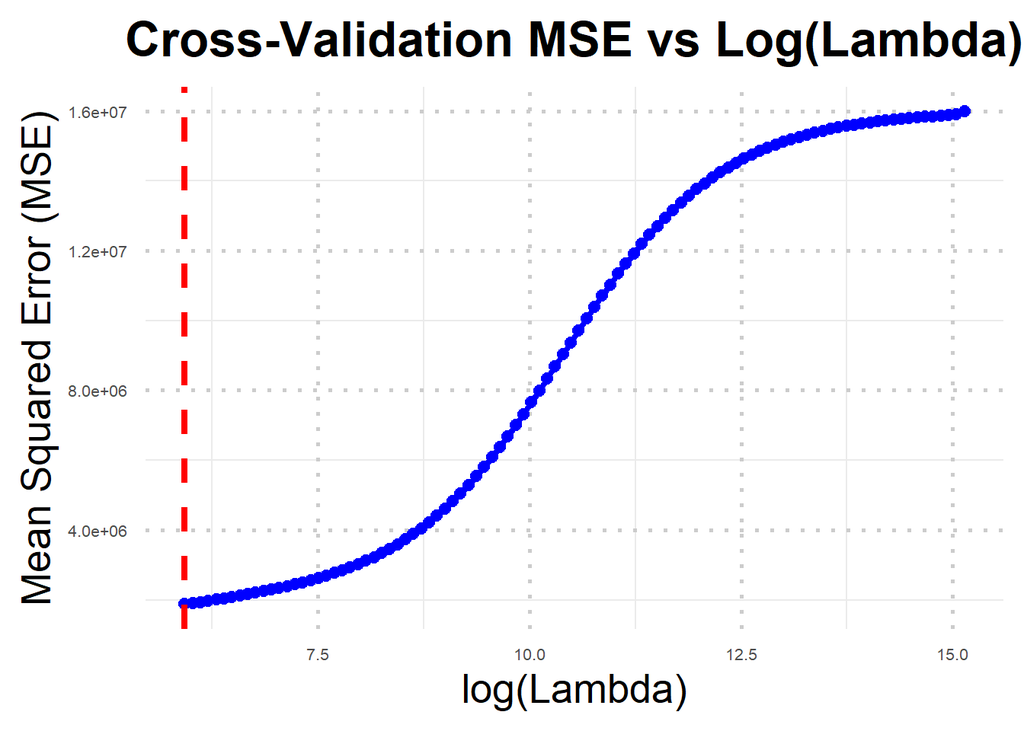

```r
# Convert lambda values to log scale
lambda_log <- log(cv_ridge$lambda)

# Create a data frame for plotting
plot_data <- data.frame(
  Lambda_Log = lambda_log,
  MSE = cv_ridge$cvm
)

# Find the log of the best lambda
best_lambda_log <- log(best_lambda)

# **Improved ggplot2 Plot with Larger Font & Bigger Size**
ggplot(plot_data, aes(x = Lambda_Log, y = MSE)) +
  geom_line(color = "blue", linewidth = 1.5) +  # Smooth blue line
  geom_point(color = "blue", size = 2.5) + # Increase dot size
  geom_vline(xintercept = best_lambda_log, color = "red", linetype = "dashed", linewidth = 1.5) +  # Best lambda line
  labs(title = "Cross-Validation MSE vs Log(Lambda)",
       x = "log(Lambda)",
       y = "Mean Squared Error (MSE)") +
  theme_minimal(base_size = 20) +  # **Increase global font size**
  theme(panel.grid.major = element_line(color = "grey80", linetype = "dotted"),
        plot.title = element_text(hjust = 0.5, size = 24, face = "bold"),
        axis.title = element_text(size = 20),
        axis.text = element_text(size = 8))
```

### Q1.d:

- Fit a lasso model on the training set, with $\lambda$ chosen by cross-validation.
- Again, Plot the MSE as a function of the log of the regularization parameter (i.e. log($\lambda$)) for several orders of magnitude.
- Also plot the number of non-zero coefficient estimates.
- Finally, report the test error obtained.

```r
# Load required libraries
library(glmnet)
library(ggplot2)

# Prepare data: Exclude the response variable from predictors
X_train <- model.matrix(Apps ~ ., data = train_set)[,-1]
y_train <- train_set$Apps
X_test <- model.matrix(Apps ~ ., data = test_set)[,-1]
y_test <- test_set$Apps

# Perform cross-validation to select the best lambda for Lasso regression
set.seed(1500)
cv_lasso <- cv.glmnet(X_train, y_train, alpha = 1)  # alpha = 1 for Lasso

# Extract the best lambda value
best_lambda_lasso <- cv_lasso$lambda.min
print(paste("Optimal lambda for Lasso:", best_lambda_lasso))
```

```
[1] "Optimal lambda for Lasso: 12.890364077917"
```

```r
# Fit the final Lasso model with the best lambda
lasso_model <- glmnet(X_train, y_train, alpha = 1, lambda = best_lambda_lasso)

# Make predictions on the test set
lasso_predictions <- predict(lasso_model, newx = X_test)

# Compute test error (MSE)
lasso_mse <- mean((y_test - lasso_predictions)^2)
print(paste("Test MSE for Lasso:", lasso_mse))
```

```
[1] "Test MSE for Lasso: 698744.654258554"
```

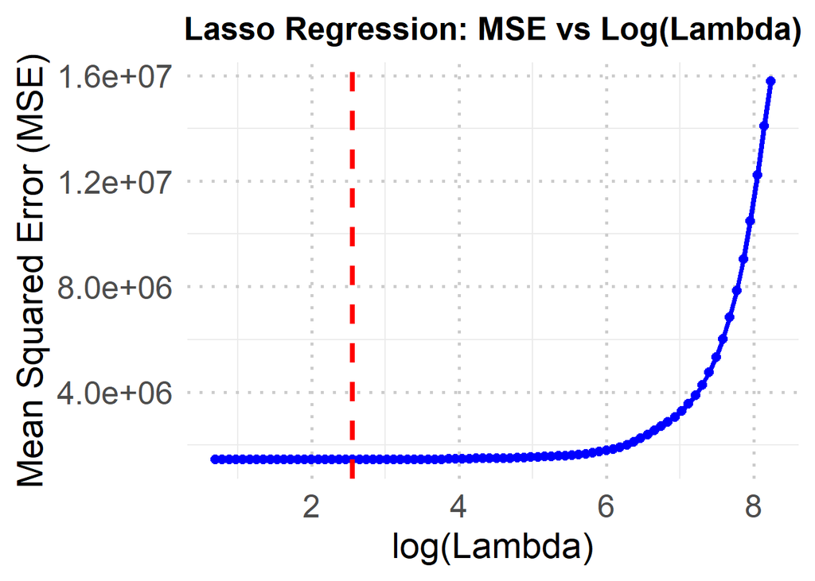

```r
# Convert lambda values to log scale
lambda_log <- log(cv_lasso$lambda)

# Create a dataframe for plotting MSE vs log(lambda)
plot_data <- data.frame(
  Lambda_Log = lambda_log,
  MSE = cv_lasso$cvm
)

# Find the log of the best lambda
best_lambda_log <- log(best_lambda_lasso)

# Plot MSE vs log(lambda)
ggplot(plot_data, aes(x = Lambda_Log, y = MSE)) +
  geom_line(color = "blue", linewidth = 1.5) +  # MSE curve
  geom_point(color = "blue", size = 2.5) + # Data points
  geom_vline(xintercept = best_lambda_log, color = "red", linetype = "dashed", linewidth = 1.5) +  # Best lambda line
  labs(title = "Lasso Regression: MSE vs Log(Lambda)",
       x = "log(Lambda)",
       y = "Mean Squared Error (MSE)") +
  theme_minimal(base_size = 20) +
  theme(panel.grid.major = element_line(color = "grey80", linetype = "dotted"),
        plot.title = element_text(hjust = 0.5, size = 20, face = "bold"),
        axis.title = element_text(size = 22),
        axis.text = element_text(size = 20))
```

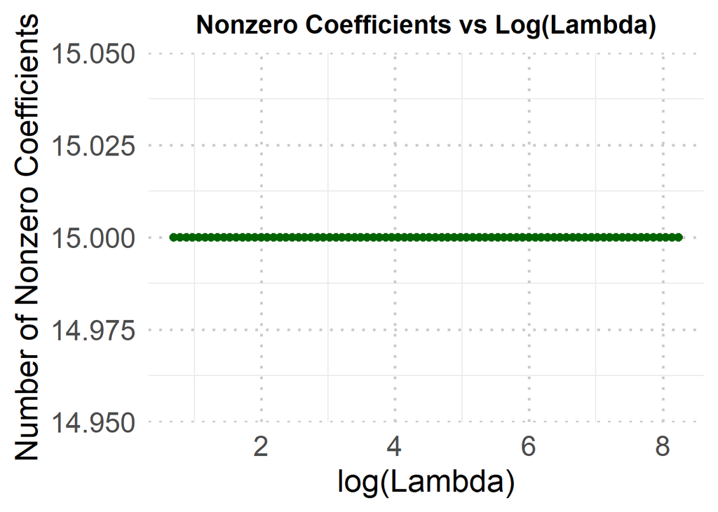

```r
coef_data <- data.frame(
  Lambda_Log = lambda_log,
  Num_Nonzero_Coefs = colSums(as.matrix(coef(cv_lasso, s = "lambda.min")) != 0) - 1,  # Exclude intercept
  row.names = NULL
)


# Plot number of nonzero coefficients vs log(lambda)
ggplot(coef_data, aes(x = Lambda_Log, y = Num_Nonzero_Coefs)) +
  geom_line(color = "darkgreen", linewidth = 1.5) +
  geom_point(color = "darkgreen", size = 2.5) +
  labs(title = "Nonzero Coefficients vs Log(Lambda)",
       x = "log(Lambda)",
       y = "Number of Nonzero Coefficients") +
  theme_minimal(base_size = 20) +
  theme(panel.grid.major = element_line(color = "grey80", linetype = "dotted"),
        plot.title = element_text(hjust = 0.5, size = 18, face = "bold"),
        axis.title = element_text(size = 22),
        axis.text = element_text(size = 20))
```

## Question-2:

Consider the **Boston** data. We want to predict **medv** from all other predictors, using the LASSO.

### Q2.a

Set up the LASSO and plot the trajectories of all coefficients. What are the last five variables to remain in the model?

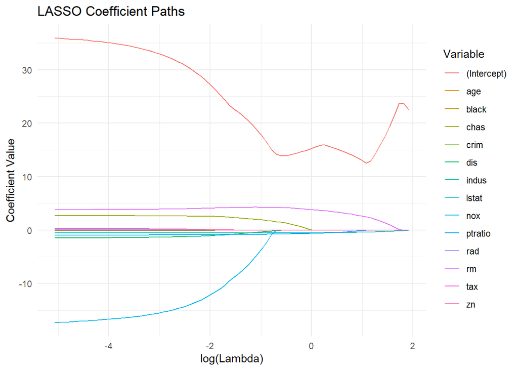

```r
suppressPackageStartupMessages({
  library(glmnet)
  library(MASS)  # Contains the Boston dataset
  library(ggplot2)
  library(dplyr)
  library(tidyr)
})

# Load the Boston dataset
data("Boston")

# Prepare data: Define predictors (X) and response variable (y)
X <- model.matrix(medv ~ ., data = Boston)[,-1]  # Remove intercept column
y <- Boston$medv

# Perform LASSO regression with cross-validation
set.seed(1500)
lasso_model <- glmnet(X, y, alpha = 1)  # alpha = 1 for LASSO

# Extract coefficient paths
coefs <- as.matrix(coef(lasso_model))

# Convert to data frame for visualization
coefs_df <- as.data.frame(t(coefs))  # Transpose to get lambda values as rows
coefs_df$lambda <- lasso_model$lambda  # Add lambda values

# Convert to long format for ggplot (FIXED)
coefs_long <- coefs_df %>%
  pivot_longer(cols = -lambda, names_to = "Variable", values_to = "Coefficient")

# Plot coefficient trajectories
ggplot(coefs_long, aes(x = log(lambda), y = Coefficient, color = Variable)) +
  geom_line() +
  labs(title = "LASSO Coefficient Paths",
       x = "log(Lambda)",
       y = "Coefficient Value") +
  theme_minimal() +
  theme(legend.position = "right")
```

```r
# Identify the last five variables to remain in the model
nonzero_counts <- apply(coefs, 1, function(x) sum(x != 0))  # Count nonzero coefficients
last_five_lambda <- lasso_model$lambda[which(nonzero_counts == 5)[1]]  # Find the first lambda with 5 nonzero coefs
last_five_vars <- rownames(coefs)[which(coefs[, which(lasso_model$lambda == last_five_lambda)] != 0)]

# Print the last five variables
print("Last five variables to remain in the LASSO model:")
```

```
[1] "Last five variables to remain in the LASSO model:"
```

```r
print(last_five_vars)
```

```
character(0)
```

### Q2.b

Find the 1SE value of $\lambda$, using 10-fold cross-validation. What is the cross validation estimate for the residual standard error?

```r
# Load libraries
library(glmnet)
library(MASS)  # Contains the Boston dataset

# Load the Boston dataset
data("Boston")

# Prepare data: Define predictors (X) and response variable (y)
X <- model.matrix(medv ~ ., data = Boston)[,-1]  # Remove intercept column
y <- Boston$medv

# Perform LASSO regression with 10-fold cross-validation
set.seed(1500)
cv_lasso <- cv.glmnet(X, y, alpha = 1, nfolds = 10)  # 10-fold CV

# Extract lambda.1se (1 standard error lambda)
lambda_1se <- cv_lasso$lambda.1se
print(paste("1SE Value of Lambda:", lambda_1se))
```

```
[1] "1SE Value of Lambda: 0.378925750098168"
```

```r
# Compute the cross-validation estimate for residual standard error (RSE)
mse_1se <- min(cv_lasso$cvm[cv_lasso$lambda == lambda_1se])  # Cross-validation MSE at lambda.1se
rse_1se <- sqrt(mse_1se)  # Residual Standard Error (RSE)

print(paste("Cross-validation estimate for Residual Standard Error (RSE):", rse_1se))
```

```
[1] "Cross-validation estimate for Residual Standard Error (RSE): 5.17208538771039"
```

### Q2.c

Rescale all predictors so that their mean is zero and their standard deviation is 1. Then set up the LASSO and plot the trajectories of all coefficients.

What are the last five variables to remain in the model? Compare your answer to part a).

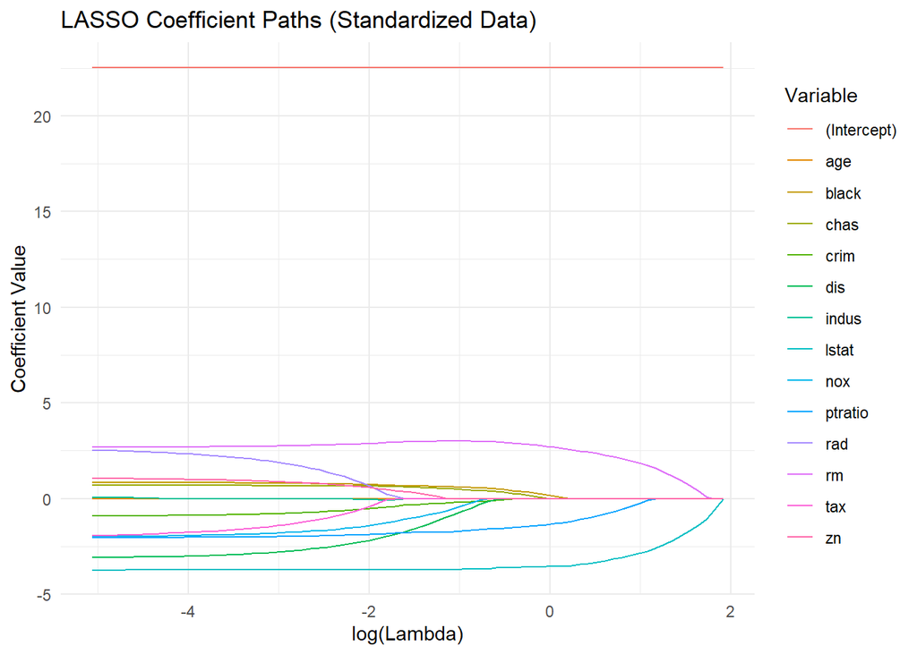

```r
# Load necessary libraries
suppressPackageStartupMessages({
  library(glmnet)
  library(MASS)  # Contains the Boston dataset
  library(ggplot2)
  library(dplyr)
  library(tidyr)
})

# Load the Boston dataset
data("Boston")

# Standardize the predictor variables
X_scaled <- scale(Boston[, -which(names(Boston) == "medv")])  # Standardize all predictors
y <- Boston$medv  # Response variable remains unchanged

# Perform LASSO regression with cross-validation
set.seed(1500)
lasso_model_scaled <- glmnet(X_scaled, y, alpha = 1)  # alpha = 1 for LASSO

# Extract coefficient paths
coefs_scaled <- as.matrix(coef(lasso_model_scaled))

# Convert to data frame for visualization
coefs_df_scaled <- as.data.frame(t(coefs_scaled))  # Transpose to get lambda values as rows
coefs_df_scaled$lambda <- lasso_model_scaled$lambda  # Add lambda values

# Convert to long format for ggplot
coefs_long_scaled <- coefs_df_scaled %>%
  pivot_longer(cols = -lambda, names_to = "Variable", values_to = "Coefficient")

# Plot coefficient trajectories
ggplot(coefs_long_scaled, aes(x = log(lambda), y = Coefficient, color = Variable)) +
  geom_line() +
  labs(title = "LASSO Coefficient Paths (Standardized Data)",
       x = "log(Lambda)",
       y = "Coefficient Value") +
  theme_minimal() +
  theme(legend.position = "right")
```

```r
# Identify the last five variables to remain in the model
nonzero_counts_scaled <- apply(coefs_scaled, 1, function(x) sum(x != 0))  # Count nonzero coefficients
last_five_lambda_scaled <- lasso_model_scaled$lambda[which(nonzero_counts_scaled == 5)[1]]  # Find the first lambda with 5 nonzero coefs
last_five_vars_scaled <- rownames(coefs_scaled)[which(coefs_scaled[, which(lasso_model_scaled$lambda == last_five_lambda_scaled)] != 0)]

# Print the last five variables
print("Last five variables to remain in the standardized LASSO model:")
```

```
[1] "Last five variables to remain in the standardized LASSO model:"
```

```r
print(last_five_vars_scaled)
```

```
character(0)
```

### Q2.d

Find the 1SE value of $\lambda$, using 10-fold cross-validation. What is the cross validation estimate for the residual standard error now? Does rescaling lead to a better performing model?

```r
# Load libraries
suppressPackageStartupMessages({
  library(glmnet)
  library(MASS)  # Contains the Boston dataset
})

# Load the Boston dataset
data("Boston")

# Standardize the predictor variables (excluding response variable)
X_scaled <- scale(Boston[, -which(names(Boston) == "medv")])  # Standardize all predictors
y <- Boston$medv  # Response variable remains unchanged

# Perform LASSO regression with 10-fold cross-validation on standardized data
set.seed(1500)
cv_lasso_scaled <- cv.glmnet(X_scaled, y, alpha = 1, nfolds = 10)  # 10-fold CV

# Extract lambda.1se (1 standard error lambda)
lambda_1se_scaled <- cv_lasso_scaled$lambda.1se
print(paste("1SE Value of Lambda (Standardized):", lambda_1se_scaled))
```

```
[1] "1SE Value of Lambda (Standardized): 0.378925750098168"
```

```r
# Compute the cross-validation estimate for residual standard error (RSE)
mse_1se_scaled <- min(cv_lasso_scaled$cvm[cv_lasso_scaled$lambda == lambda_1se_scaled])  # CV MSE at lambda.1se
rse_1se_scaled <- sqrt(mse_1se_scaled)  # Residual Standard Error (RSE)

print(paste("Cross-validation estimate for Residual Standard Error (Standardized Data):", rse_1se_scaled))
```

```
[1] "Cross-validation estimate for Residual Standard Error (Standardized Data): 5.17208538771039"
```

The model did not perform better after scaling because the Residual Standard Error (RSE) remains unchanged. This indicates that glmnet() has already performed the standardization that can be done so there is no need to rescale the data set.